# Analyze select-pics image norming experiment

```r
library(dplyr)
library(tidyr)
library(stringr)
library(ggplot2)
library(datapasta)
library(directlabels)
library(lme4)
source("../../../shared_resources/helpers.R")
fullPalette <- c("#394165", "#A65141")
toughPalette <- c("#394165")
valleyPalette <-c("#A65141")
```

#Get data, wrangle data

```r
data <- read.csv('../data/raw/norm_imgs_selectpics_real-trials.csv')
n_distinct(data $workerid)
```

```
[1] 130
```

```r
data.tidy <- data %>%
  select(-Answer.condition) %>%
  mutate(full_set = gsub("\\[|]|'|,", '', full_set)) %>%
  mutate(ladies_selected = gsub("\\[|]|'|,", '', ladies_selected)) %>%
  mutate(trial = workerid) %>%
  group_by(trial) %>%
  mutate(presentation_in_trial = row_number()) %>%
  ungroup

full_set <- data.tidy %>%
  select(-ladies_selected) %>%
  mutate(ladies = strsplit(as.character(full_set), " ")) %>%
    unnest(ladies) %>%
  unique()

selected <- data.tidy %>%
  select(-full_set) %>%
  mutate(ladies = strsplit(as.character(ladies_selected), " ")) %>%
    unnest(ladies) %>%
  unique()


joined <- full_join(full_set, selected, by = c("trial", "presentation_in_trial", "ladies"))
joined.tidy <- joined %>%
  select(-full_set,-ladies_selected) %>%
  mutate(yesorno = ifelse(is.na(descriptor.y), 0, 1)) %>%
  select(-descriptor.y, -Answer.time_in_minutes.y, -rt.y, -workerid.y) %>%
  rename(descriptor = descriptor.x, total_answer_time = Answer.time_in_minutes.x, rt = rt.x, workerid = workerid.x) %>%
  mutate(persona = str_split_fixed(ladies, '_', n=3)[,1],
         head = str_split_fixed(ladies, '_', n=3)[,2],
         bod = str_split_fixed(ladies, '_', n=3)[,3]) %>%
  mutate(bhair = ifelse(persona == 'v' & head == 'h1' |
                          persona == 'v' & head == 'h2' |
                          persona == 'v' & head == 'h3' |
                          persona == 'v' & head == 'h5' |
                          persona == 'v' & head == 'h6', 1, 0)) %>%
  mutate(pants = ifelse (persona == 'v' & bod == 'b2' |
                           persona == 'v' & bod == 'b6' |
                           persona == 't' & bod == 'b2' |
                           persona == 't' & bod == 'b3' |
                           persona == 't' & bod == 'b4' |
                           persona == 't' & bod == 'b6', 1, 0))

summary(joined.tidy)
```

```
    workerid     total_answer_time       rt         why_no_select.x           descriptor       trial
 Min.   :  0.0   Min.   : 1.304    Min.   : -4411          :8720    feminine       :1040   Min.   :  0.0
 1st Qu.: 32.0   1st Qu.: 2.325    1st Qu.:  7584   3      :  40    from California:1040   1st Qu.: 32.0
 Median : 64.5   Median : 3.007    Median : 11706   1      :  32    from New York  :1040   Median : 64.5
 Mean   : 64.5   Mean   : 4.103    Mean   : 17471   5      :  32    masculine      :1040   Mean   : 64.5
 3rd Qu.: 97.0   3rd Qu.: 4.698    3rd Qu.: 20134   7      :  24    materialistic  :1040   3rd Qu.: 97.0
 Max.   :129.0   Max.   :24.028    Max.   :328941   8      :  24    sociable       :1040   Max.   :129.0
                                                    (Other):1528    (Other)        :4160
 presentation_in_trial    ladies                                                        why_no_select.y    yesorno
 Min.   : 1.0          Length:10400                                                             :3697   Min.   :0.0000
 1st Qu.: 3.0          Class :character   I believe they all are female                         :   8   1st Qu.:0.0000
 Median : 5.5          Mode  :character   I selected everyone                                   :   8   Median :0.0000
 Mean   : 5.5                             NY is full of every type of person                    :   8   Mean   :0.3939
 3rd Qu.: 8.0                             The one girl has a tom boy look with those short hair.:   7   3rd Qu.:1.0000
 Max.   :10.0                             (Other)                                               : 369   Max.   :1.0000
                                          NA's                                                  :6303
   persona              head               bod                bhair            pants
 Length:10400       Length:10400       Length:10400       Min.   :0.0000   Min.   :0.0000
 Class :character   Class :character   Class :character   1st Qu.:0.0000   1st Qu.:0.0000
 Mode  :character   Mode  :character   Mode  :character   Median :0.0000   Median :0.0000
                                                          Mean   :0.3727   Mean   :0.4127
                                                          3rd Qu.:1.0000   3rd Qu.:1.0000
                                                          Max.   :1.0000   Max.   :1.0000
```

```r
sd(joined.tidy$total_answer_time)
```

```
[1] 3.168579
```

## filter bad actors (bots, click farms)

```r
attn.df <- joined.tidy %>%
  filter(descriptor == 'with blonde hair' | descriptor == 'wearing pants') %>% # included to filter out bots etc
  group_by(workerid, descriptor) %>%
  mutate(bhair_acc = ifelse(descriptor == 'with blonde hair' & yesorno == bhair,1,
                            ifelse(descriptor == 'with blonde hair' & yesorno != bhair,
                                   0, NA)),
         pants_acc = ifelse(descriptor == 'wearing pants' & yesorno == pants,1,
                            ifelse(descriptor == 'wearing pants' & yesorno != pants,
                                   0, NA))) %>%
 summarize(bhair_total_acc = mean(bhair_acc), na.rm = TRUE, pants_total_acc = mean(pants_acc), na.rm = TRUE)%>%
  select(-descriptor, -na.rm) %>%
  gather(var, val, bhair_total_acc, pants_total_acc) %>%
  na.omit()%>%
  unique() %>%
  spread(var, val) %>%
  mutate(total_acc = mean (bhair_total_acc + pants_total_acc)/2)

#total accuracy
acc.plot <- attn.df %>%
  gather(var, val, bhair_total_acc:total_acc) %>%
  ggplot(aes(x=val, fill = var )) +
  geom_bar(position ='dodge')
acc.plot

#EXAMINE BAD ACTORS
#don't filter on total accuracy, as this could mean NO attn being paid to one of the catchers. Instead, allow 75% accuracy for each (ie. can get two wrong each time)
bad <- attn.df %>%
  filter(bhair_total_acc < 0.75 | pants_total_acc < 0.75)

exclude_ids <- bad$workerid
clean <- joined.tidy %>%
  filter(!workerid  %in% exclude_ids)
write.csv(clean, '../data/clean/cleaned_selectpics_data.csv')

# reporting N and N exclusions for writeup
n_total <- as.data.frame(clean$workerid)%>%
  unique()
n_total

clean$ladies <- as.factor(clean$ladies)
n_ladies <- clean %>%
  filter(descriptor != 'wearing pants' )%>%
  filter(descriptor != 'with blonde hair')%>%
  group_by(ladies) %>%
  mutate(n_judgments = n())
n_ladies
summary(n_ladies)

n_distinct(clean$workerid)
```

```r
judgments <- clean %>%
  filter(descriptor != 'wearing pants' )%>%
  filter(descriptor != 'with blonde hair')%>%
  group_by(persona, descriptor) %>%
  summarise(judgments_mean = mean(yesorno), CI.Low = ci.low(yesorno),
            CI.High = ci.high(yesorno))%>%
  mutate(YMin = judgments_mean - CI.Low, YMax = judgments_mean + CI.High)
judgments
```

```r
judgments_per_img <- clean %>%
 filter(descriptor != 'wearing pants' )%>%
  filter(descriptor != 'with blonde hair')%>%
  group_by(ladies) %>%
  summarize(n = n())
judgments_per_img
```

| ladies | n |
| --- | --- |
| t_h1_b1 | 69 |
| t_h1_b2 | 71 |
| t_h1_b3 | 65 |
| t_h1_b4 | 71 |
| t_h1_b5 | 69 |
| t_h1_b6 | 72 |
| t_h1_b7 | 68 |
| t_h2_b1 | 70 |
| t_h2_b2 | 74 |
| t_h2_b3 | 66 |

[output cut: 92 more lines]

```r
summary(judgments_per_img)
```

```
     ladies         n
 t_h1_b1: 1   Min.   :53.00
 t_h1_b2: 1   1st Qu.:66.00
 t_h1_b3: 1   Median :68.50
 t_h1_b4: 1   Mean   :68.39
 t_h1_b5: 1   3rd Qu.:72.00
 t_h1_b6: 1   Max.   :76.00
 (Other):96
```

# visualize

[figure not shown]

```r
ind_judgments <- joined.tidy %>%
  filter(descriptor != 'wearing pants' )%>%
  filter(descriptor != 'with blonde hair')%>%
  group_by(persona, descriptor, ladies) %>%
  summarise(judgments_mean = mean(yesorno), total_judgments = n())

ind.plot <- ggplot(ind_judgments, aes(x = ladies, y = judgments_mean, color = persona)) +
  geom_jitter() +
  facet_wrap(~descriptor) +
  #scale_color_manual(values=tastyPalette) +
  theme(axis.title.x=element_blank(),
        axis.text.x=element_blank(),
        axis.ticks.x=element_blank()) +
  ylab("mean ratings")
ind.plot

summary(ind_judgments) #mean 10.2 judgments per persona / descriptor
n_distinct(ind_judgments$ladies) # 102, the full set (all imgs were judged at least once)
```

HEADS AND BODIES - for each persona, ratings of heads + bodies separated - just to explore whether one element much more ‘meaningful’ - i.e. bearing weight of semiotic info

```r
heads_bods <- joined.tidy %>%
  mutate(head = gsub('h', '', str_split_fixed(ladies, '_', n=3)[,2]),
         body = gsub('b', '',  str_split_fixed(ladies, '_', n=3)[,3])) %>%
  gather(var, val, head,body) %>%
  group_by(persona, descriptor, var, val) %>%
  summarise(judgments_mean = mean(yesorno), CI.Low = ci.low(yesorno),
            CI.High = ci.high(yesorno))%>%
  mutate(YMin = judgments_mean - CI.Low, YMax = judgments_mean + CI.High)

tough_hb_bar.plot <- heads_bods %>%
  filter(persona == 't') %>%
  ggplot(aes(x = val, y = judgments_mean, fill = var)) +
  geom_bar(stat = 'identity', position='dodge') +
  geom_errorbar(position='dodge', width=0.9, aes(ymin=YMin,ymax=YMax), width=.25) +
  facet_wrap(~descriptor) +
  #scale_fill_manual(values=tastyPalette) +
  xlab('head/body no.') +
  ylab("mean ratings")
tough_hb_bar.plot

val_hb_bar.plot <- heads_bods %>%
  filter(persona == 'v') %>%
  ggplot(aes(x = val, y = judgments_mean, fill = var)) +
  geom_bar(stat = 'identity', position='dodge') +
  geom_errorbar(position='dodge', width=0.9, aes(ymin=YMin,ymax=YMax), width=.25) +
  facet_wrap(~descriptor) +
  scale_fill_manual(values=tastyPalette) +
  xlab('head/body no.') +
  ylab("mean ratings")
val_hb_bar.plot
```

MODELS

```r
spread.df <- joined.tidy %>%
  spread(descriptor, yesorno) %>%
  rename(from_CA = 'from California', from_NY = 'from New York',streetsmart = 'street smart')
spread.df

fem.mod <- glmer(feminine ~ persona + (1|ladies), family = binomial, data = spread.df)
summary(fem.mod)

tough.mod <- glmer(tough ~ persona + (1|ladies), family = binomial, data = spread.df)
summary(tough.mod)

tough.mod <- glm(tough ~ persona, family = binomial, data = spread.df)
summary(tough.mod)

ny.mod <- glmer(from_NY ~ persona + (1|ladies), family = binomial, data = spread.df)
summary(ny.mod)

ca.mod <- glmer(from_CA ~ persona + (1|ladies), family = binomial, data = spread.df)
summary(ca.mod)

streetsmart.mod <- glmer(streetsmart ~ persona + (1|ladies), family = binomial, data = spread.df)
summary(streetsmart.mod)

materialistic.mod <- glmer(materialistic ~ persona + (1|ladies), family = binomial, data = spread.df)
summary(materialistic.mod)

sociable.mod <- glmer(sociable ~ persona + (1|ladies), family = binomial, data = spread.df)
summary(sociable.mod)
```

### DETERMINING THE EXPERIMENTAL SET

Whiich images are the best exemplars of tough/valley? - calculate Tough scores (mean of all ‘tough’ features) - calculate Valley scores (mean of all ‘valley’ features) - tough_diff = tough_score - valley_score (i.e. the toughscore minus the ‘penalty’ valley score); vice versa

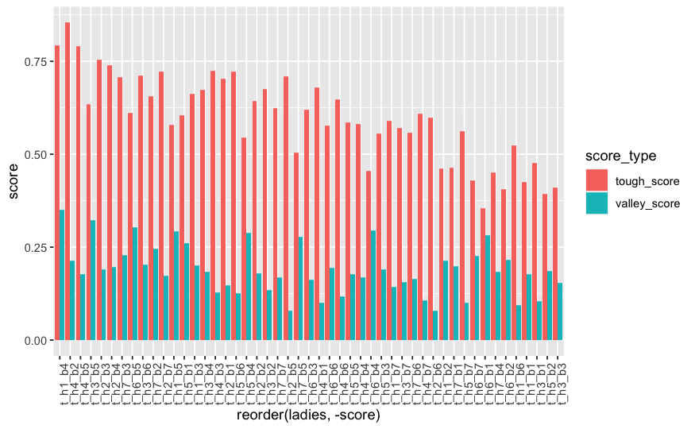

```r
summed <- ind_judgments %>%
  select(persona, ladies, descriptor, judgments_mean) %>%
  group_by(ladies) %>%
  spread(descriptor, judgments_mean)%>%
  rename(from_CA = 'from California', from_NY = 'from New York', streetsmart = 'street smart') %>%
  mutate(tough_score = (masculine+tough+streetsmart+from_NY)/4)%>%
  mutate(valley_score = (feminine+materialistic+sociable+from_CA)/4) %>%
  mutate(tough_diff = tough_score - valley_score,
         valley_diff = valley_score - tough_score) %>%
  gather(score_type, score, tough_score, valley_score)

summed$ladies <- as.factor(summed$ladies)
summed$score_type <- as.factor(summed$score_type)

#tough and valley scores on same plot, for Toughs
t_both.plot <-summed %>%
  filter(persona == 't') %>%
  ggplot() +
  geom_bar(stat = "identity",
           position = 'dodge',
           aes(x=reorder(ladies, -score), y=score, fill = score_type)) +
  theme(axis.text.x = element_text(angle = 90, hjust = 1))
t_both.plot
```

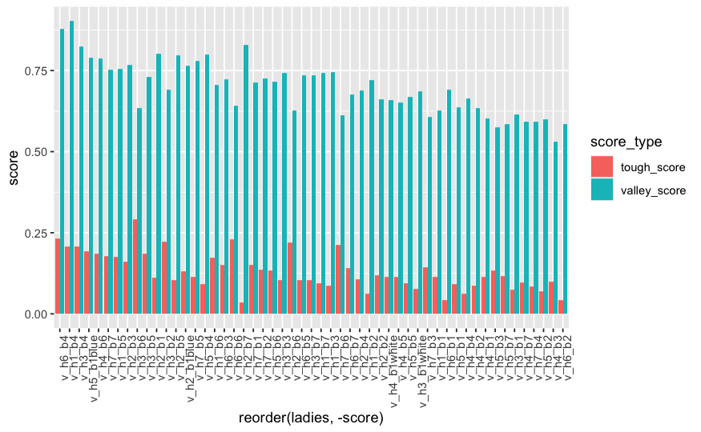

```r
#tough and valley scores on same plot, for Valleys
v_both.plot <-summed %>%
  filter(persona == 'v') %>%
  ggplot() +
  geom_bar(stat = "identity",
           position = 'dodge',
           aes(x=reorder(ladies, -score), y=score, fill = score_type)) +
  theme(axis.text.x = element_text(angle = 90, hjust = 1))
v_both.plot
```

- plots indicate that there don’t seem to be any ‘ambiguous’ cases (ie where tough and valley scores are near parity)

```r
summed.tidy <- summed %>%
  mutate(score_type = recode_factor(score_type,  tough_score ="Tough score", valley_score = "Valley Girl score"))
summed.tidy

ind_scores <- summed.tidy %>%
  ggplot() +
  geom_histogram(aes(x=score, fill = persona))+
  scale_fill_manual(values=fullPalette, name = "Persona type", breaks= c("t", "v"), labels = c("Tough", "Valley Girl"))+
  facet_wrap(~score_type) +
  xlim(0,1) +
  ylab("No. of images")+
  xlab("Score") +
 theme(legend.position = "bottom",
       axis.title.x = element_blank(),
       legend.title = element_blank(),
       axis.text.x = element_text(color="black", size=14),
       axis.text.y = element_text(size = 14),
       axis.title.y = element_text(color="black", size=16),
       legend.text = element_text(color="black", size=14),
       strip.text.x = element_text(color="black", size=14)
          )
ind_scores
ggsave('../plots/ind_scores.png', ind_scores, width=9, height=4)
ggsave('../plots/ind_scores.pdf', ind_scores, width=9, height=4)
```

# Select images

Need 24 of the best exemplars of Toughs and Valleys to use as experimental stimuli. Current set includes 7 unique heads, 7 unique bodies per persona type. ideal world - max 3-4 head repetitions, max 3-4 body repetitions

```r
rankings <- summed %>%
  select(persona, ladies, tough_diff, valley_diff)%>%
  unique() %>%
  ungroup %>%
  #top_n(32, tough_diff) %>%
  mutate(head = str_split_fixed(ladies, '_', n=3)[,2],
         bod = str_split_fixed(ladies, '_', n=3)[,3])

rankings$ladies <- as.factor(rankings$ladies)
rankings$head <- as.factor(rankings$head)
rankings$bod <- as.factor(rankings$bod)

summary(rankings)
```

```
   persona              ladies     tough_diff        valley_diff       head         bod
 Length:102         t_h1_b1: 1   Min.   :-0.79286   Min.   :-0.64111   h1:14   b1     :14
 Class :character   t_h1_b2: 1   1st Qu.:-0.57465   1st Qu.:-0.41245   h2:15   b2     :14
 Mode  :character   t_h1_b3: 1   Median :-0.40323   Median : 0.40323   h3:15   b3     :14
                    t_h1_b4: 1   Mean   :-0.09802   Mean   : 0.09802   h4:15   b4     :14
                    t_h1_b5: 1   3rd Qu.: 0.41245   3rd Qu.: 0.57465   h5:15   b5     :14
                    t_h1_b6: 1   Max.   : 0.64111   Max.   : 0.79286   h6:14   b6     :14
                    (Other):96                                         h7:14   (Other):18
```

Allow for max 5 body / head repetitions take top 24

TOUGHS:

```r
rankings <- arrange(rankings, desc(tough_diff))
top_toughs <- rankings %>%
  filter(persona == 't') %>%
  group_by(head) %>%
  mutate(head_count = row_number()) %>%
  ungroup %>%
  group_by(bod) %>%
  mutate(bod_count = row_number()) %>%
  mutate(yes = ifelse(head_count < 6 & bod_count < 6, 'yes', 'no')) %>%
  filter(yes == 'yes') %>%
  ungroup %>%
  top_n(24, tough_diff)

top_toughs
```

VALLEYS

```r
rankings <- arrange(rankings, desc(valley_diff))
top_valleys <- rankings %>%
  filter(persona == 'v') %>%
  group_by(head) %>%
  mutate(head_count = row_number()) %>%
  ungroup %>%
  group_by(bod) %>%
  mutate(bod_count = row_number()) %>%
  mutate(yes = ifelse(head_count < 6 & bod_count < 6, 'yes', 'no')) %>%
  filter(yes == 'yes') %>%
  ungroup %>%
  top_n(24, valley_diff)
top_valleys
```

MAKE NEW DIRECTORIES OF THE SELECTED TOUGHS AND VALLEYS

```r
src <- '/Users/daisydorothy/Desktop/proj/eyeballs/experiments/norming/norm_pics/norm_pics_selectpics/exp/static/images/'
tough_src <- top_toughs %>%
  select(ladies) %>%
  mutate(fname = paste(src, ladies, '.jpg', sep = '')) %>%
  select(-ladies)

new_toughs <- '/Users/daisydorothy/Desktop/proj/eyeballs/design/stim_creation/imgs/selected_imgs/toughs/'
#file.copy(tough_src$fname, new_toughs)


valley_src <- top_valleys %>%
  select(ladies) %>%
  mutate(fname = paste(src, ladies, '.jpg', sep = '')) %>%
  select(-ladies)

new_valleys <- '/Users/daisydorothy/Desktop/proj/eyeballs/design/stim_creation/imgs/selected_imgs/valleys/'
#file.copy(valley_src$fname, new_valleys)
```

UPDATE JUNE 2020: ING EXPERIMENT (12 CRITICAL TRIALS, NO CONTROL TRIALS WITH TWO VALLEYS OR TOUGHS)

```r
top_12_toughs <- rankings %>%
  filter(persona == 't') %>%
  group_by(head) %>%
  mutate(head_count = row_number()) %>%
  ungroup %>%
  group_by(bod) %>%
  mutate(bod_count = row_number()) %>%
  mutate(yes = ifelse(head_count < 4 & bod_count < 4, 'yes', 'no')) %>%
  filter(yes == 'yes') %>%
  ungroup %>%
  top_n(12, tough_diff)



top_12_valleys <- rankings %>%
  filter(persona == 'v') %>%
  group_by(head) %>%
  mutate(head_count = row_number()) %>%
  ungroup %>%
  group_by(bod) %>%
  mutate(bod_count = row_number()) %>%
  mutate(yes = ifelse(head_count < 4 & bod_count < 4, 'yes', 'no')) %>%
  filter(yes == 'yes') %>%
  ungroup %>%
  top_n(12, valley_diff)
top_12_valleys
```

Update October 2020; now I want 16 toughs, 16 valleys

```r
rankings$headrec <- 1
rankings$bodrec <- 1
top_ts <- rankings %>%
  filter(persona == 't') %>%
  arrange(desc(tough_diff))%>%
  group_by(head) %>%
  mutate("head_count" = cumsum(headrec)) %>%
  ungroup %>%
  group_by(bod) %>%
  mutate("bod_count" = cumsum(bodrec)) %>%
  select(-headrec, -bodrec) %>%
  filter(head_count < 5 & bod_count < 5) %>%
  ungroup %>%
  top_n(16, tough_diff)

top_vs <- rankings %>%
  filter(persona == 'v') %>%
  arrange(desc(valley_diff))%>%
  group_by(head) %>%
  mutate("head_count" = cumsum(headrec)) %>%
  ungroup %>%
  group_by(bod) %>%
  mutate("bod_count" = cumsum(bodrec)) %>%
  select(-headrec, -bodrec) %>%
  filter(head_count < 5 & bod_count < 5) %>%
  ungroup %>%
  top_n(16, valley_diff)


# Put them in their directory
tpath <- '/Users/daisy/Desktop/proj/eyeballs/design/stim_creation/imgs/selected_imgs/toughs_resized_167x500/'
tough_src <- top_ts %>%
  select(ladies) %>%
  mutate(fname = paste(tpath, ladies, '.png', sep = '')) %>%
  select(-ladies)

outdir <- '/Users/daisy/Desktop/proj/eyeballs/experiments/categorical/NSP_stims/IN/static/imgs/'
file.copy(tough_src$fname, outdir)


vpath <- '/Users/daisy/Desktop/proj/eyeballs/design/stim_creation/imgs/selected_imgs/valleys_resized_167x500/'
valley_src <- top_vs %>%
  select(ladies) %>%
  mutate(fname = paste(vpath, ladies, '.png', sep = '')) %>%
  select(-ladies)
file.copy(valley_src$fname, outdir)
```

[output not shown]